# FLW High Frequency Surveys

09 October 2020

## West Bengal Survey Data

We surveyed 4363 ASHA workers across villages in West Bengal over 5 months from May-September 2020. Once an ASHA worker agreed to enroll in our survey, we contacted her every 3 days and asked her questions related to symptom reports, number of confirmed coronavirus cases in her area, the number of house visits conducted by her, equipment she had received, challenges faced, the number of children vaccinated, usage of masks and social distancing in her area. We managed to complete on average, 8.6 interview rounds with a single ASHA.

NOTE: All of the N's in the graphs reflect the total number of unique ASHAs surveyed.

### Symptom + Covid Trends

For each symptom, plotted the average number of cases that FLWs came across over the previous 3 days.

That is = Case counts reported by all FLWs surveyed on a particular day/# of FLWs surveyed on that day.

Note: We did not conduct any surveys from July 5-August 5.

1. Fever

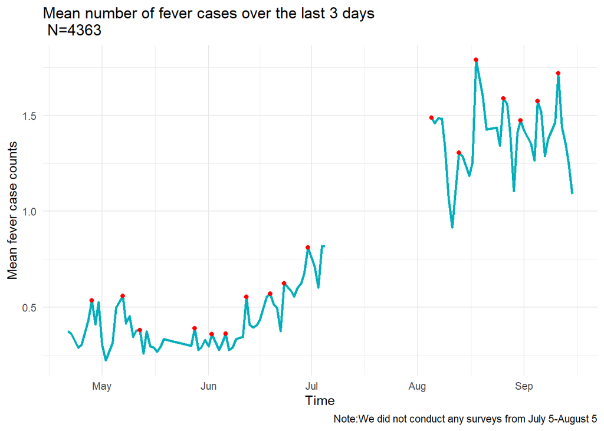

2. Cough

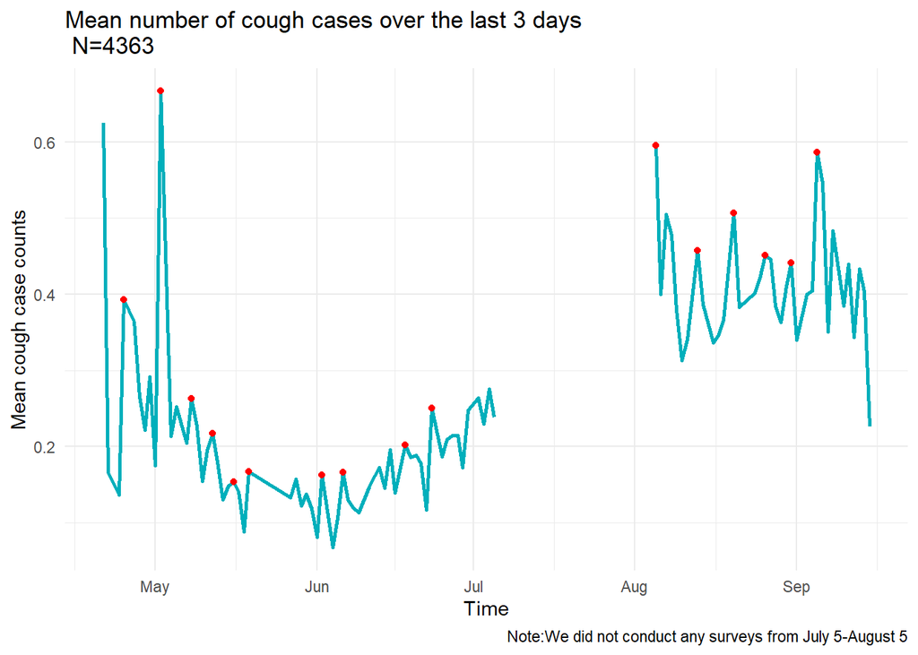

3. Loss of smell

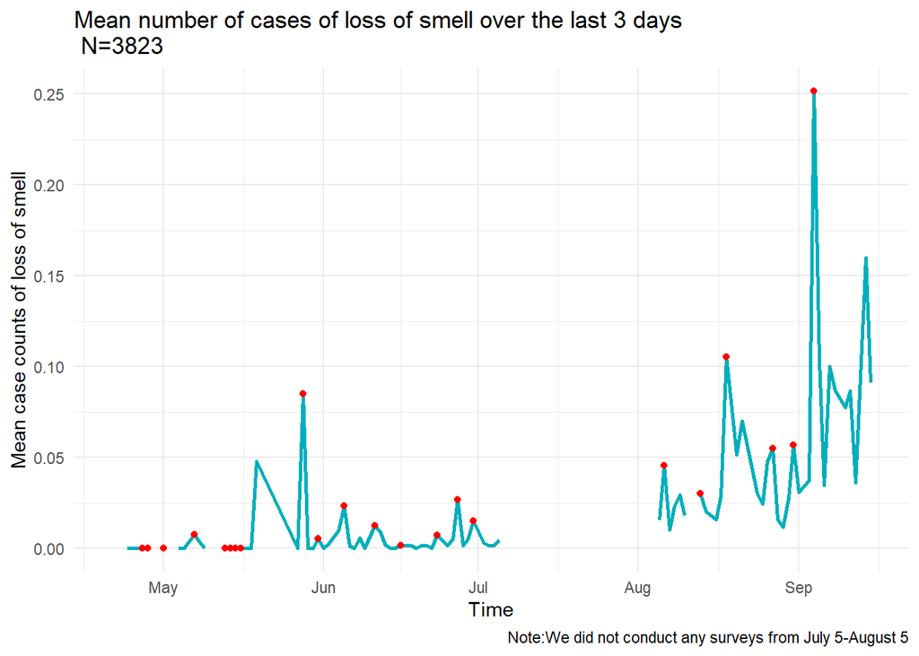

4. Covid toes

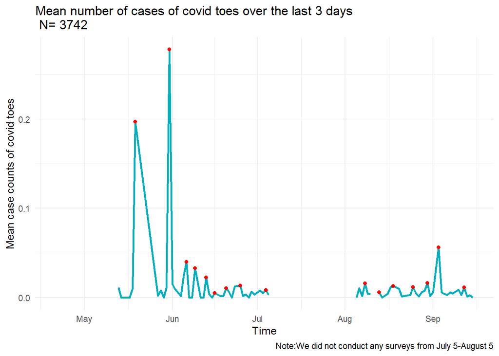

5. Confirmed coronavirus cases

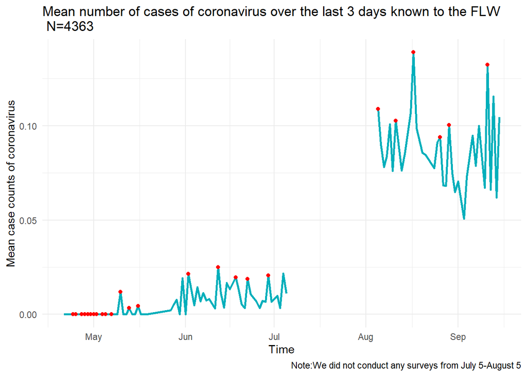

### FLW Symptoms

We also asked FLWs whether they themselves were experiencing any symptoms.

For each symptom, we have plotted the proportion of FLWs who mentioned they were experiencing this symptom, each survey day. That is: Total # of FLWs who mentioned experiencing the symptom/# of FLWs who were asked this question on that survey day.

Note: We did not conduct any surveys from July 5-August 5.

1. Fever

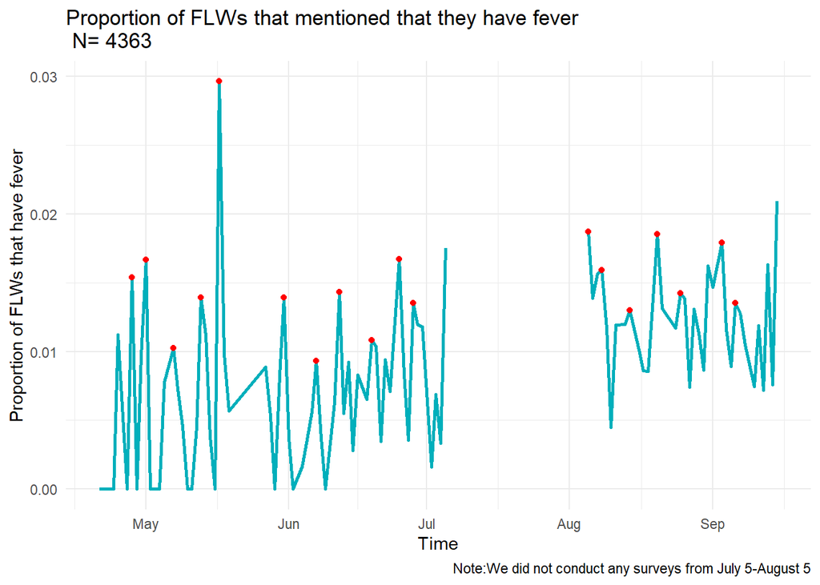

2. Cough

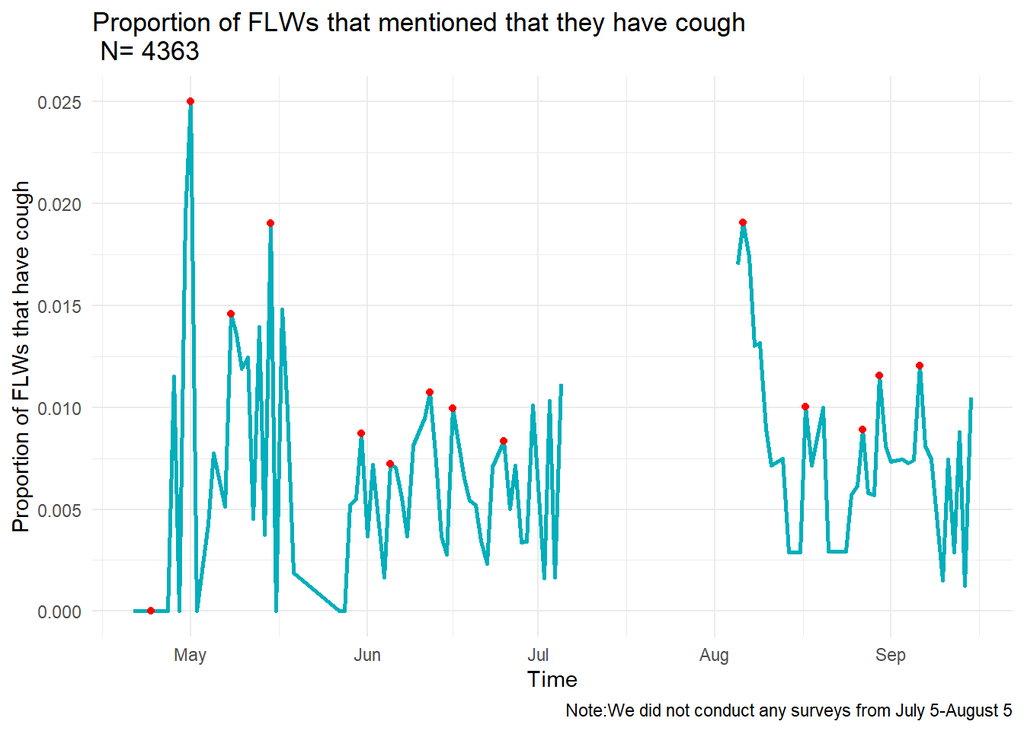

3. Loss of ability to smell/taste

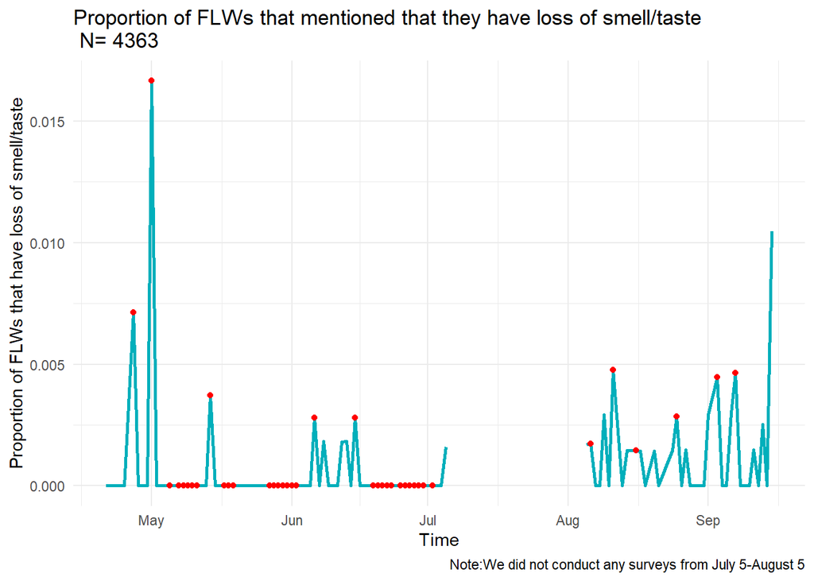

4. Shortness of breath/difficulty breathing

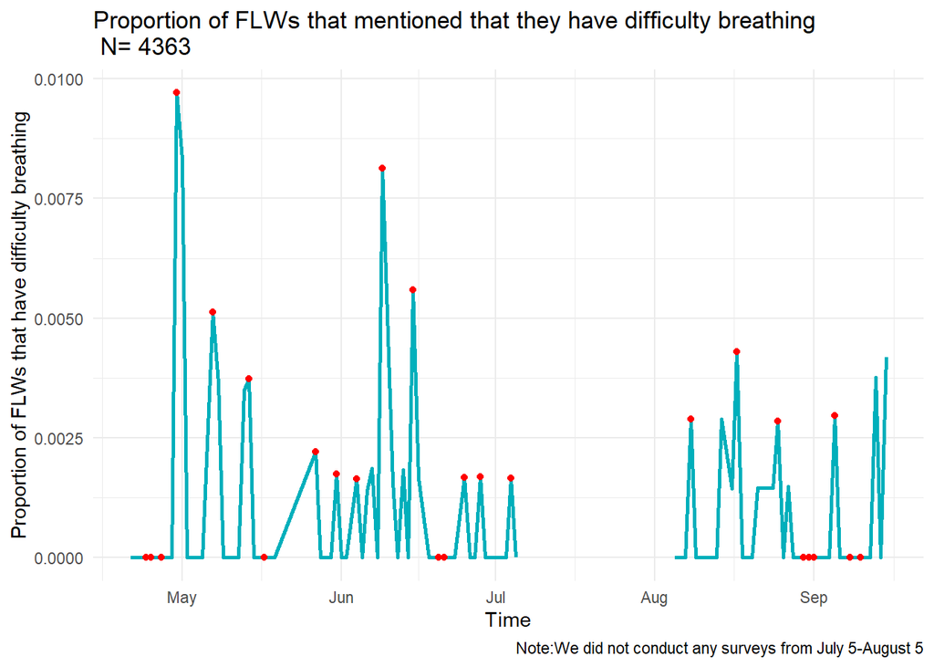

### Home visits, Equipment, Challenges Faced

Note: We did not conduct any surveys from July 5-August 5.

1. Proportion of homes visited

The below graph shows the average proportion of houses visited by FLWs (in the last 3 days), out of the total number of households that come under their jurisdiction.

We calculate the proportion of households visited by an FLW in the last 3 days as: # of households visited in last 3 days/total number of households in that FLWs jurisdiction.

We then plot the average of the above number, for all FLWs surveyed on a particular day.

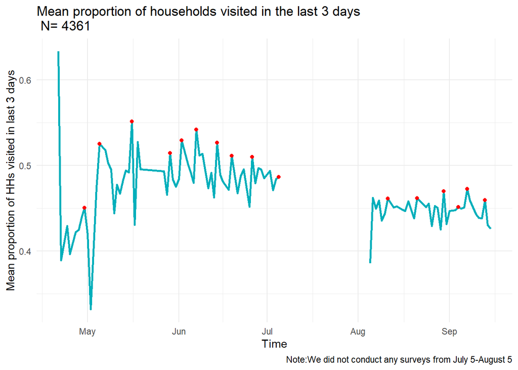

2. Equipment

Number of FLWs who mentioned that they received various equipment. We plot the equipment received by 4363 ASHAs, across ALL their interview rounds.

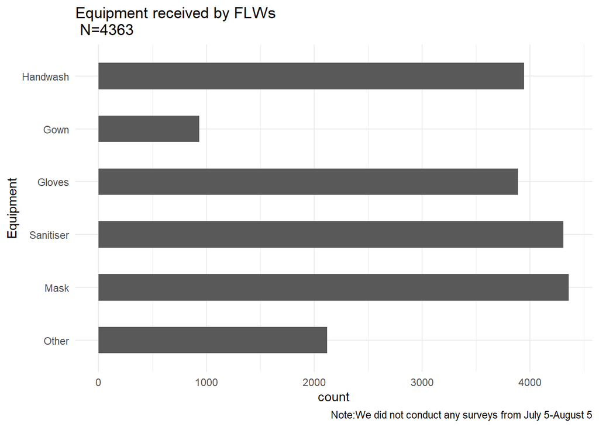

2. Equipment given by government

Out of the equipment that FLWs have mentioned, the ones that were given to them by the government.We plot the equipment received by 4363 ASHAs, across ALL their interview rounds.

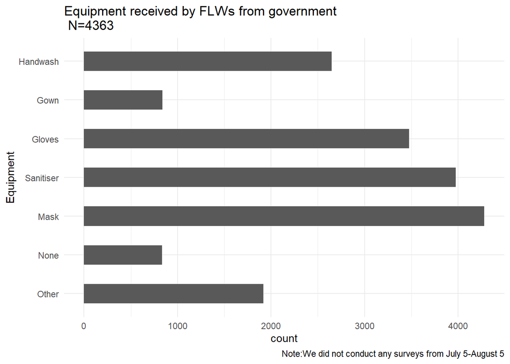

3. Challenges faced by FLWs

Number of FLWs who mentioned various challenges (without probing).We plot the challenges faced by 4363 ASHAs, across ALL their interview rounds.

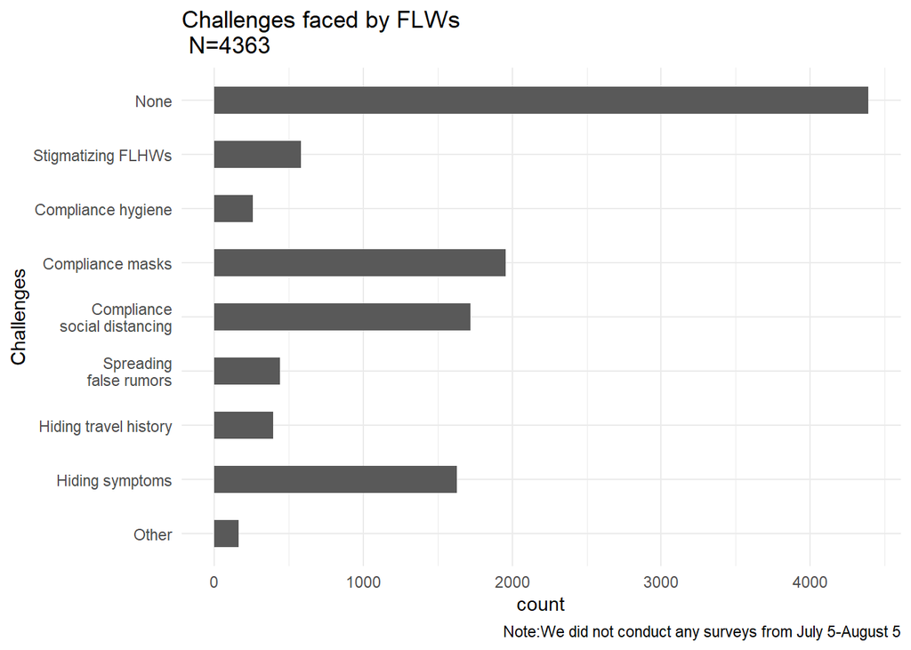

4. Challenges faced by FLWs

Number of FLWs who mentioned various challenges (without probing+ probed responses).We plot the challenges faced by 4363 ASHAs, across ALL their interview rounds.

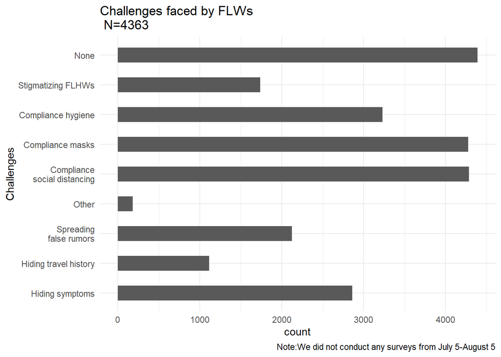

### Immunization, Pregnant Women, TB Tests

Note: We did not conduct any surveys from July 5-August 5.

1. Children Vaccinated

The below graph shows count of children in the FLW's area that were vaccinated in the last 7 days.

We plot the average of the above number, for all FLWs surveyed on a particular day.

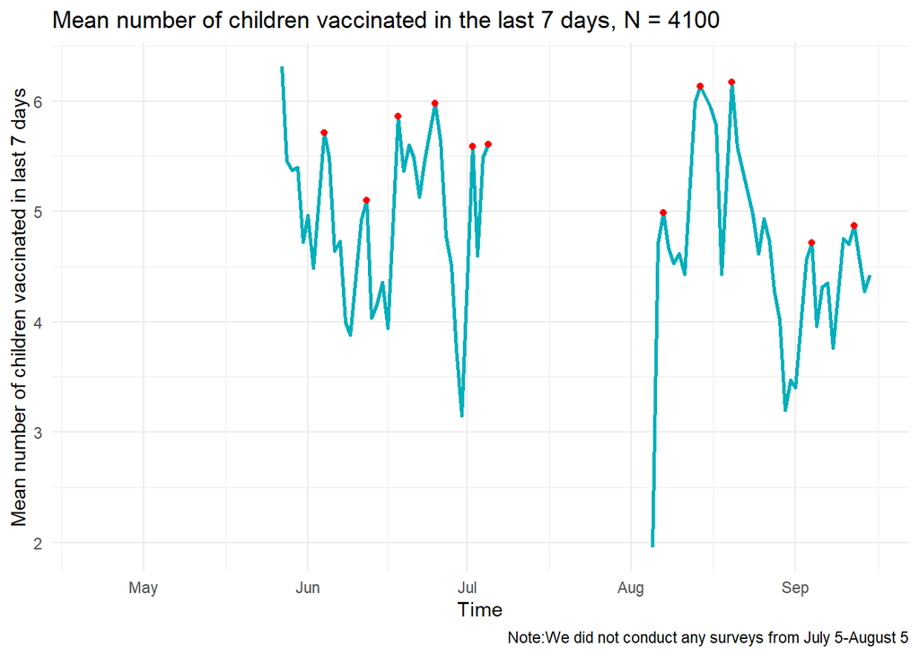

2. Vaccination Supply

The below graph shows the proportion of FLWs that reported having adequate supply of vaccines for the current month on a particular day.

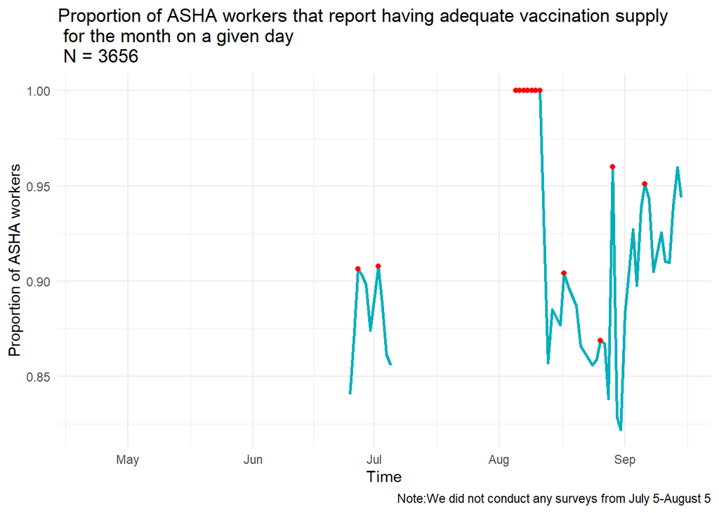

3. Pregnant Women House Visits

The below graph shows the number of pregnant women visited by the FLW in the last 7 days.

We then plot the average of the above number, for all FLWs surveyed on a particular day.

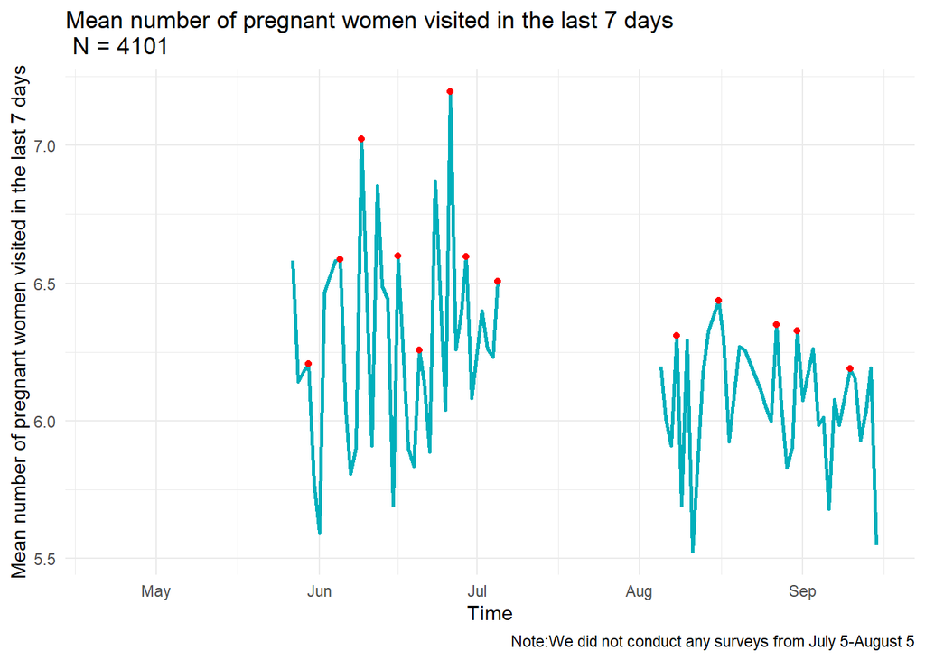

4. TB Cough Tests

The below graph shows the number of people sent for a TB cough test by the FLW in the last 7 days.

We then plot the average of the above number, for all FLWs surveyed on a particular day.

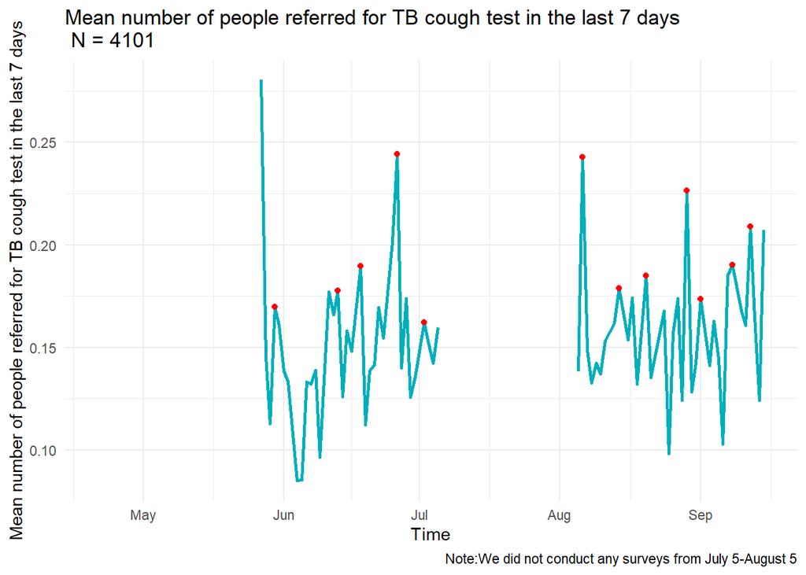

### Masks, Social Distancing

Note: We did not conduct any surveys from July 5-August 5.

1. Mask Usage

The below graph shows how many people (out of 100) in the FLWs area covered their nose and mouth with a mask/face covering when stepping out.

We then plot the average of the above number, for all FLWs surveyed on a particular day.

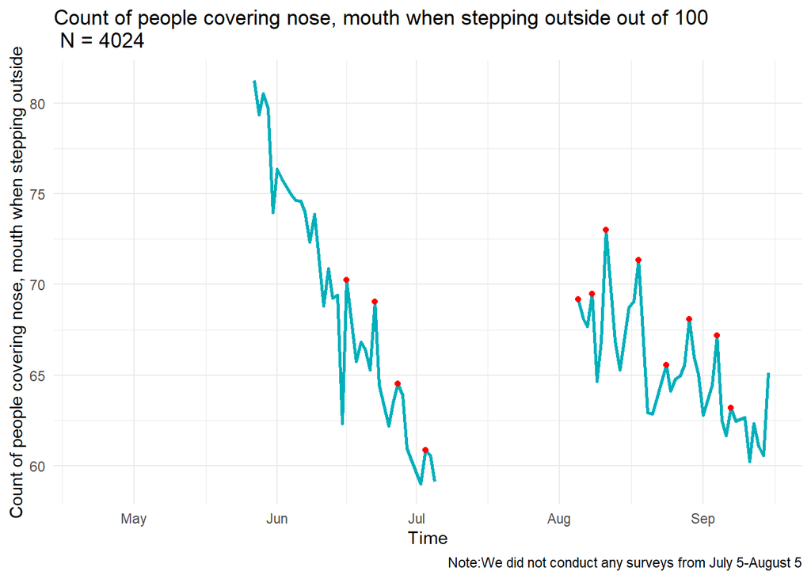

2. Public Gathering/Socializing

The below graph shows approximately how many people were seen in a public gathering place in the village (such as tea stalls, parks) in the last 2 days (yesterday and day before yesterday).

We then plot the average of the above number, for all FLWs surveyed on a particular day.

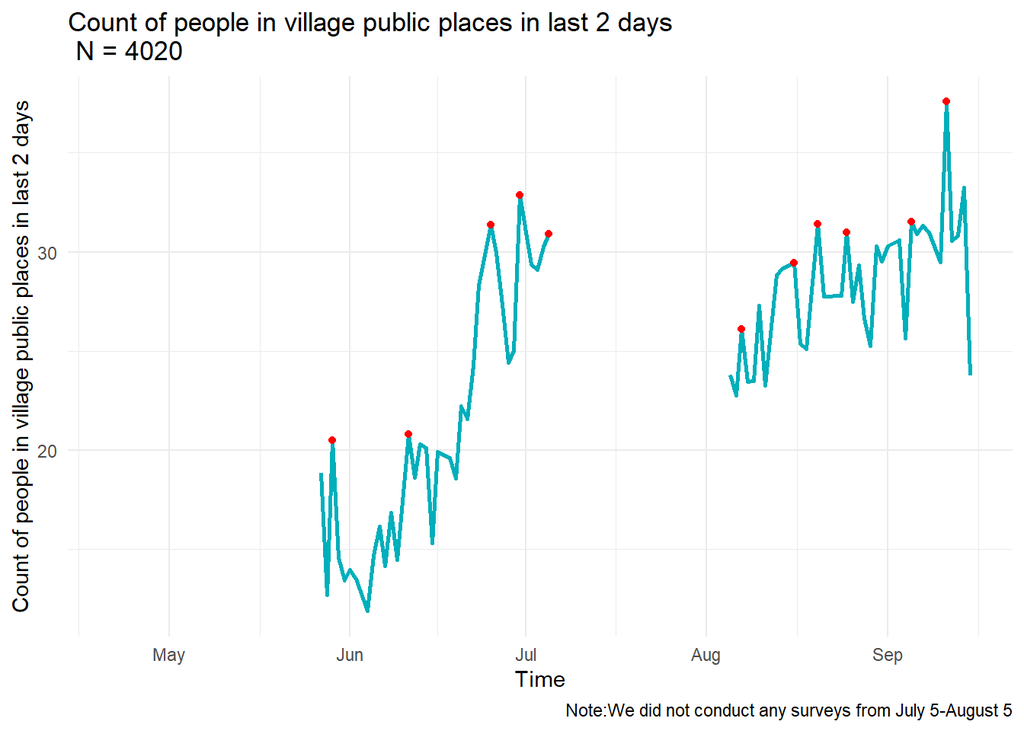